# Week 4 Notes

Published

September 29, 2025

## Notes

#### WHY use Spatial Analysis

- WHERE are these patterns occurring matters
  - Geographic clustering of problems
  - Spatial relationships between communities
  - Access to services and resources is often based on geography

#### Spatial Data Fundamentals

- Two families of representing world 2-dimensionally
  - Vector
    - discrete objects – things that have definite boundaries
  - Raster
    - Pixels
    - Continuous data

**Vector Data Representation** - Three basic types of geometric representations - points - lines - polygons - (kinda like illustrator)

**Common Spatial Data File Formats** - Shapefile - Developed by ESRI - Three fundamental objects (need all three to render accurately): - `.shp` - stores info about the geometry - `.shx` - shape index - `.dbf` - names of things - Integrates with tidyverse, follows inernational standards - GeoJSON - All one file ! Little more - KML - Google Earth - Database connections (PostGIS)

**Simple Features** - Multi-shapes – like a broken bridge – think multiple shapes for one row of a table - Think Hawaii - -multiple shapes that are all “Hawaii”

TidyCensus gives you characteristics but no shapes, tigris gives you shapes but no characteristics – must combine

**Important syntax:**

- ==ggplot geom for mapping: `geom_sf()`==
- ==ggplot use `theme_void()` to get rid of graph backdrop==
- ==`st_filter()` is like `filter()` but for spatial filtering rather than simple df`
- `st_union()` works like arcgis “dissolve”

**Spatial Subsetting:** - preserves original shapes, not for doing something like finding part of a county. Rather for doing things like finding a county within a list of counties, or all counties that touch a specific county

`neighbors <- pa_counties %>% st_filter(allegheny, .predicate = st_touches)`

- In this example, the terminology “st_touches” is common across all GIS
- `.predicate` tells `st_filter()` what kind of relationship to look for, if nothing specified, then `st_intersect` is default

**cheat sheet:**

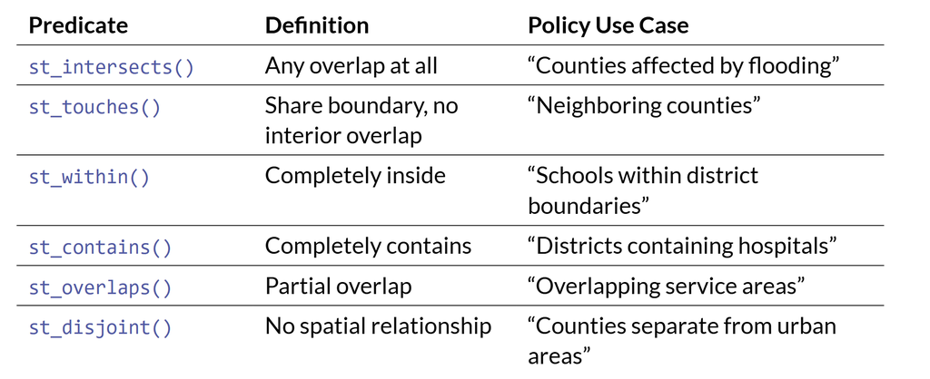

cheat-sheet

#### Coordinate Reference System (CRS)

- basic problem : world is round, maps are flat, projecting from 3d to 2d will necessarily cause some kind of distortion
- Earth is also not perfectly round, but a geoid ( a lil bumpy ), but geoid is mathematically inconvenient, so the **Step 1** in projection is we project from he geoid to an ==ellipsoid==, which doesn’t perfectly represent the geoid, but good enough, and smooth
  - This means there are multiple ellipsoids that fit the earth, and might fit certain areas better than others

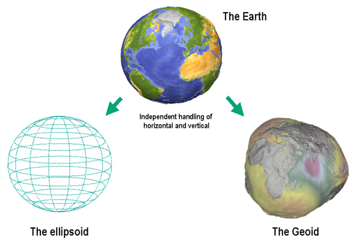

crs

- **Step 2** – tie the ellipsoid to the real earth to create a **Geographic (Geodetic) Coordinate System** i.e. Lat Longs
  - Clark, 1866, uses ‘flattening’ to make a nice lil ellipsoid that is particularly well-fitted to North America – Meades Ranch, Kansas, is where the ellipsoid and geoid smooch :-*
  - ==North American Datum 1927== or ==NAD27==
  - Progress made, made a better ellipsoid than Clarke (“We’re not in Kansas anymore”), based on Earth Center instead of NA.. this one called ==GRS80==
  - ==WGS84== – yet another used by GPS systems
- **Step 3** – take the 3d ellipsoid points and project onto 2d surface
  - Cylindrical Projections

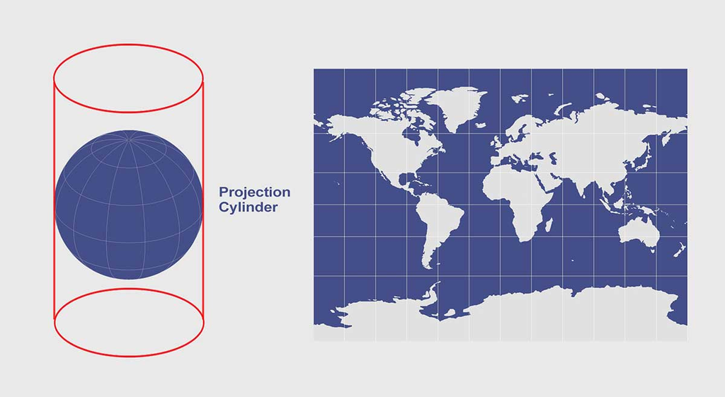

cylindical-projections

```
    -   Line of tangency -- where the ellipsoid and the projected
        surface smooch, all other locations will be distorted
    -   Mercator is prime example
    -   Bad at preserving sizes of things on 2d surface, but good at
        preserving angles
-   Transverse Cylindrical Projection
    -   Good at preserving up and down (good for Chile, for example)
```

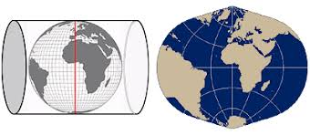

transverse

```
-   Conical Projection
    -   Good for areas concentrated in a segment of the ellipsoid,
        like North America
```

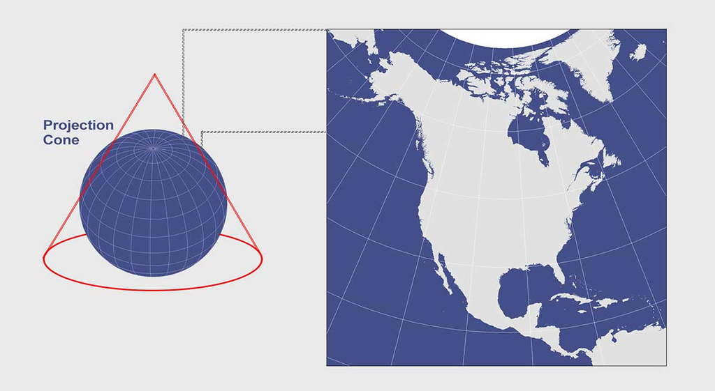

conical

```
-   Projected Coordinate System
    -   Localized coordinate system built on a regular,
        non-distorted grid
    -   ==UTM== --
```

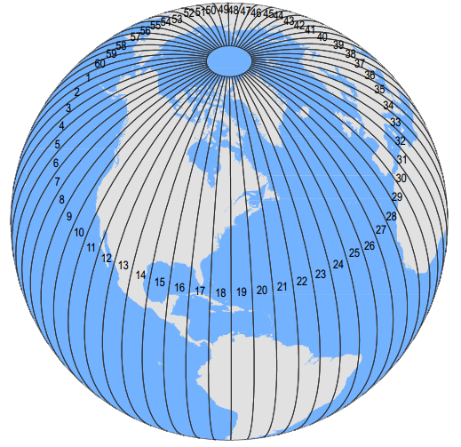

UTM

```
        -   Need to know what zone you are in -- all numbers are
            based on grid system originating in the lower left
            corner of the zone
        -   No negatives
        -   Who uses UTM ? depends on state -- if looking at a long
            skinny area like Idaho for example
    -   ==State Plane== (SPC)
        -   Used in PA - Two state plane grids in PA, North and
            South
```

[figure not shown]

state-plane

```
        -   Some states use Feet, others use Meters -- make sure to
            check !
-   SADD -- can't have all 4 in a projection
    -   Shape
    -   Area
    -   Distance
    -   Direction
```

- `st_crs()` to check CRS for a dataset
- `st_set_crs(data, ####)` – set CRS – ONLY IF CRS MISSING, do NOT use to transform CRS (path of despair) – this will not change the numbers themselves but rather how the computer interprets the numbers, only use if `st_crs()` returns `<unknown>`
- `st_transform()` – this will actually recalculate the coordinates from one CRS to another
- In arcGIS – this is the like the difference between “define projection” and “project”